# RAINBOW: Reliable Association INference By Optimizing Weights with R

Kosuke Hamazaki (hamazaki@ut-biomet.org)

Hiroyoshi Iwata

2019-09-26

In this repository, the `R` package `RAINBOW` is available. Here, we describe how to install and how to use `RAINBOW`.

## What is `RAINBOW`

`RAINBOW`(Reliable Association INference By Optimizing Weights with R) is a package to perform several types of `GWAS` as follows.

- Single-SNP GWAS with `RGWAS.normal` function
- SNP-set (or gene set) GWAS with `RGWAS.multisnp` function (which tests multiple SNPs at the same time)
- Check epistatic (SNP-set x SNP-set interaction) effects with `RGWAS.epistasis` (very slow and less reliable)

`RAINBOW` also offers some functions to solve the linear mixed effects model.

- Solve one-kernel linear mixed effects model with `EMM.cpp` function
- Solve multi-kernel linear mixed effects model with `EM3.cpp` function (for the general kernel, not so fast)
- Solve multi-kernel linear mixed effects model with `EM3.linker.cpp` function (for the linear kernel, fast)

By utilizing these functions, you can estimate the genomic heritability and perform genomic prediction (`GP`).

Finally, `RAINBOW` offers other useful functions.

- `qq` and `manhattan` function to draw Q-Q plot and Manhattan plot
- `modify.data` function to match phenotype and marker genotype data
- `CalcThreshold` function to calculate thresholds for GWAS results
- `See` function to see a brief view of data (like `head` function, but more useful)
- `genetrait` function to generate pseudo phenotypic values from marker genotype
- `SS_GWAS` function to summarize GWAS results (only for simulation study)

## Installation

The stable version of `RAINBOW` is now available at the [CRAN (Comprehensive R Archive Network)](https://cran.r-project.org/package=RAINBOW). The latest version of `RAINBOW` is also available at the `KosukeHamazaki/RAINBOW` repository in the [`GitHub`](https://github.com/KosukeHamazaki/RAINBOW), so please run the following code in the R console.

```r
#### Stable version of RAINBOW ####
install.packages("RAINBOW")


#### Latest version of RAINBOW ####
### If you have not installed yet, ...
install.packages("devtools")

### Install RAINBOW from GitHub
devtools::install_github("KosukeHamazaki/RAINBOW")
```

If you get some errors via installation, please check if the following packages are correctly installed.

- Rcpp
- RcppEigen
- rrBLUP
- rgl
- tcltk
- Matrix
- cluster
- MASS

In `RAINBOW`, since part of the code is written in `Rcpp` (`C++` in `R`), please check if you can use `C++` in `R`. For `Windows` users, you should install [`Rtools`](https://cran.r-project.org/bin/windows/Rtools/).

If you have some questions about installation, please contact us by e-mail (hamazaki@ut-biomet.org).

## Usage

First, import `RAINBOW` package and load example datasets. These example datasets consist of marker genotype (scored with {-1, 0, 1}, 1,536 SNP chip (Zhao et al., 2010; PLoS One 5(5): e10780)), map with physical position, and phenotypic data (Zhao et al., 2011; Nature Communications 2:467). Both datasets can be downloaded from `Rice Diversity` homepage (http://www.ricediversity.org/data/).

```r
### Import RAINBOW
require(RAINBOW)

### Load example datasets
data("Rice_Zhao_etal")
Rice_geno_score <- Rice_Zhao_etal$genoScore
Rice_geno_map <- Rice_Zhao_etal$genoMap
Rice_pheno <- Rice_Zhao_etal$pheno

### View each dataset
See(Rice_geno_score)
```

```
#>                  L1        L2        L3        L4        L5        L6
#> class     <integer> <integer> <integer> <integer> <integer> <integer>
#> id1000223         1         1        -1        -1        -1        -1
#> id1000556        -1        -1         1         1        -1         1
#> id1000673        -1         1        -1         1        -1         1
#> id1000830        -1         1         1         1         1         1
#> id1000955        -1         1         1         1        -1         1
#> id1001073        -1        -1        -1         1         1        -1
#> [1] "class: data.frame"
#> [1] "dimension: 1311 x 395"
```

```r
See(Rice_geno_map)
```

```
#>              marker       chr       pos
#> class      <factor> <integer> <integer>
#> id1000223 id1000223         1    420422
#> id1000556 id1000556         1    655693
#> id1000673 id1000673         1    740153
#> id1000830 id1000830         1    913806
#> id1000955 id1000955         1   1041748
#> id1001073 id1001073         1   1172387
#> [1] "class: data.frame"
#> [1] "dimension: 1311 x 3"
```

```r
See(Rice_pheno)
```

```
#>       Flowering.time.at.Arkansas Flowering.time.at.Faridpur
#> class                  <numeric>                  <integer>
#> L1                   75.08333333                         64
#> L3                          89.5                         66
#> L4                          94.5                         67
#> L5                          87.5                         70
#> L6                   89.08333333                         73
#> L7                           105                       <NA>
#>       Flowering.time.at.Aberdeen FT.ratio.of.Arkansas.Aberdeen
#> class                  <integer>                     <numeric>
#> L1                            81                   0.926954733
#> L3                            83                   1.078313253
#> L4                            93                   1.016129032
#> L5                           108                   0.810185185
#> L6                           101                   0.882013201
#> L7                           158                   0.664556962
#>       FT.ratio.of.Faridpur.Aberdeen Culm.habit
#> class                     <numeric>  <numeric>
#> L1                      0.790123457          4
#> L3                      0.795180723        7.5
#> L4                      0.720430108          6
#> L5                      0.648148148        3.5
#> L6                      0.722772277          6
#> L7                             <NA>          3
#> [1] "class: data.frame"
#> [1] "dimension: 413 x 36"
```

You can check the original data format by `See` function. Then, select one trait (here, `Flowering.time.at.Arkansas`) for example.

```r
### Select one trait for example
trait.name <- "Flowering.time.at.Arkansas"
y <- Rice_pheno[, trait.name, drop = FALSE]
```

For GWAS, first you can remove SNPs whose MAF <= 0.05 by `MAF.cut` function.

```r
### Remove SNPs whose MAF <= 0.05
x.0 <- t(Rice_geno_score)
MAF.cut.res <- MAF.cut(x.0 = x.0, map.0 = Rice_geno_map)
x <- MAF.cut.res$x
map <- MAF.cut.res$map
```

```r
### Estimate genomic relationship matrix (GRM)
K.A <- calcGRM(genoMat = x)
```

Next, we modify these data into the GWAS format of `RAINBOW` by `modify.data` function.

```r
### Modify data
modify.data.res <- modify.data(pheno.mat = y, geno.mat = x, map = map,
                               return.ZETA = TRUE, return.GWAS.format = TRUE)
pheno.GWAS <- modify.data.res$pheno.GWAS
geno.GWAS <- modify.data.res$geno.GWAS
ZETA <- modify.data.res$ZETA

### View each data for RAINBOW
See(pheno.GWAS)
```

```
#>       Sample_names Flowering.time.at.Arkansas
#> class  <character>                  <numeric>
#> L1              L1                   75.08333
#> L3              L3                   89.50000
#> L4              L4                   94.50000
#> L5              L5                   87.50000
#> L6              L6                   89.08333
#> L7              L7                  105.00000
#> [1] "class: data.frame"
#> [1] "dimension: 383 x 2"
```

```r
See(geno.GWAS)
```

```
#>          marker     chrom       pos        L1        L3        L4
#> class  <factor> <integer> <integer> <integer> <integer> <integer>
#> 1     id1000223         1    420422         1        -1        -1
#> 2     id1000556         1    655693        -1         1         1
#> 3     id1000673         1    740153        -1        -1         1
#> 4     id1000830         1    913806        -1         1         1
#> 5     id1000955         1   1041748        -1         1         1
#> 6     id1001073         1   1172387        -1        -1         1
#> [1] "class: data.frame"
#> [1] "dimension: 1264 x 386"
```

```r
str(ZETA)
```

```
#> List of 1
#>  $ A:List of 2
#>   ..$ Z: num [1:383, 1:383] 1 0 0 0 0 0 0 0 0 0 ...
#>   .. ..- attr(*, "dimnames")=List of 2
#>   .. .. ..$ : chr [1:383] "L1" "L3" "L4" "L5" ...
#>   .. .. ..$ : chr [1:383] "L1" "L3" "L4" "L5" ...
#>   ..$ K: num [1:383, 1:383] 1.0112 -0.45 -0.417 -0.0454 -0.4051 ...
#>   .. ..- attr(*, "dimnames")=List of 2
#>   .. .. ..$ : chr [1:383] "L1" "L3" "L4" "L5" ...
#>   .. .. ..$ : chr [1:383] "L1" "L3" "L4" "L5" ...
```

`ZETA` is a list of genomic relationship matrix (GRM) and its design matrix.

Finally, we can perform `GWAS` using these data. First, we perform single-SNP GWAS by `RGWAS.normal` function as follows.

```r
### Perform single-SNP GWAS
normal.res <- RGWAS.normal(pheno = pheno.GWAS, geno = geno.GWAS,
                           plot.qq = FALSE, plot.Manhattan = FALSE,
                           ZETA = ZETA, n.PC = 4, P3D = TRUE, count = FALSE)
```

```
#> [1] "GWAS for trait: Flowering.time.at.Arkansas"
#> [1] "Variance components estimated. Testing markers."
#> Time difference of 8.091391 secs
```

```r
See(normal.res$D)  ### Column 4 contains -log10(p) values for markers
```

```
#>          marker     chrom       pos Flowering.time.at.Arkansas
#> class  <factor> <integer> <integer>                  <numeric>
#> 1     id1000223         1    420422                  0.4947884
#> 2     id1000556         1    655693                  0.3805264
#> 3     id1000673         1    740153                  0.3443145
#> 4     id1000830         1    913806                  0.1364735
#> 5     id1000955         1   1041748                  1.0212213
#> 6     id1001073         1   1172387                  0.5772127
#> [1] "class: data.frame"
#> [1] "dimension: 1264 x 4"
```

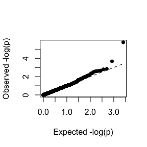

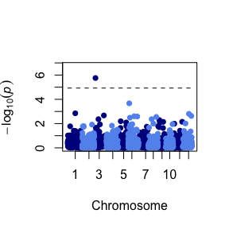

Next, we perform SNP-set GWAS by `RGWAS.multisnp` function.

```r
### Perform SNP-set GWAS (by regarding 11 SNPs as one SNP-set, first 300 SNPs)
SNP_set.res <- RGWAS.multisnp(pheno = pheno.GWAS, geno = geno.GWAS[1:300, ], ZETA = ZETA,
                              plot.qq = FALSE, plot.Manhattan = FALSE, count = FALSE,
                              n.PC = 4, test.method = "LR", kernel.method = "linear", gene.set = NULL,
                              test.effect = "additive", window.size.half = 5, window.slide = 11)
```

```
#> [1] "GWAS for trait: Flowering.time.at.Arkansas"
#> Time difference of 1.963879 mins
```

```r
See(SNP_set.res$D)  ### Column 4 contains -log10(p) values for markers
```

```
#>          marker     chrom       pos Flowering.time.at.Arkansas
#> class  <factor> <integer> <integer>                  <numeric>
#> 1     id1000223         1    420422                  0.0000000
#> 12    id1002158         1   2723270                  0.0000000
#> 23    id1004109         1   5067948                  0.3292917
#> 34    id1005263         1   6972700                  0.0000000
#> 45    id1007975         1  11107052                  0.0000000
#> 56    id1009557         1  14413616                  0.0000000
#> [1] "class: data.frame"
#> [1] "dimension: 28 x 4"
```

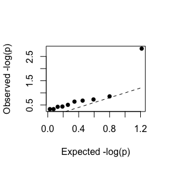

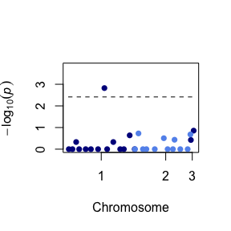

You can perform SNP-set GWAS with sliding window by setting `window.slide = 1`. And you can also perform gene-set (or haplotype-based) GWAS by assigning the following data set to `gene.set` argument.

ex.)

| gene (or haplotype block) | marker |
| --- | --- |
| gene_1 | id1000556 |
| gene_1 | id1000673 |
| gene_2 | id1000830 |
| gene_2 | id1000955 |
| gene_2 | id1001516 |
| … | … |

### Help

If you have some help before performing `GWAS` with `RAINBOW`, please see the help for each function by `?function_name`. You can also check how to determine each argument by

```r
RGWAS.menu()
```

`RGWAS.menu` function asks some questions, and by answering these question, the function tells you how to determine which function use and how to set arguments.

## References

Kennedy, B.W., Quinton, M. and van Arendonk, J.A. (1992) Estimation of effects of single genes on quantitative traits. J Anim Sci. 70(7): 2000-2012.

Storey, J.D. and Tibshirani, R. (2003) Statistical significance for genomewide studies. Proc Natl Acad Sci. 100(16): 9440-9445.

Yu, J. et al. (2006) A unified mixed-model method for association mapping that accounts for multiple levels of relatedness. Nat Genet. 38(2): 203-208.

Kang, H.M. et al. (2008) Efficient Control of Population Structure in Model Organism Association Mapping. Genetics. 178(3): 1709-1723.

Kang, H.M. et al. (2010) Variance component model to account for sample structure in genome-wide association studies. Nat Genet. 42(4): 348-354.

Zhang, Z. et al. (2010) Mixed linear model approach adapted for genome-wide association studies. Nat Genet. 42(4): 355-360.

Endelman, J.B. (2011) Ridge Regression and Other Kernels for Genomic Selection with R Package rrBLUP. Plant Genome J. 4(3): 250.

Endelman, J.B. and Jannink, J.L. (2012) Shrinkage Estimation of the Realized Relationship Matrix. G3 Genes, Genomes, Genet. 2(11): 1405-1413.

Su, G. et al. (2012) Estimating Additive and Non-Additive Genetic Variances and Predicting Genetic Merits Using Genome-Wide Dense Single Nucleotide Polymorphism Markers. PLoS One. 7(9): 1-7.

Zhou, X. and Stephens, M. (2012) Genome-wide efficient mixed-model analysis for association studies. Nat Genet. 44(7): 821-824.

Listgarten, J. et al. (2013) A powerful and efficient set test for genetic markers that handles confounders. Bioinformatics. 29(12): 1526-1533.

Lippert, C. et al. (2014) Greater power and computational efficiency for kernel-based association testing of sets of genetic variants. Bioinformatics. 30(22): 3206-3214.

Jiang, Y. and Reif, J.C. (2015) Modeling epistasis in genomic selection. Genetics. 201(2): 759-768.